# IE 582

# HOMEWORK 4

# MERT IŞIK-2019702075

Import Libraries

```python
import pandas as pd
import numpy as np
import matplotlib.pyplot as plt
import seaborn as sns
from sklearn.preprocessing import OrdinalEncoder      ##encoder for ordinal output variables
from sklearn.preprocessing import LabelEncoder
from sklearn.model_selection import train_test_split  ##test and train split
from sklearn.linear_model import LassoCV
from sklearn.tree import DecisionTreeClassifier
from sklearn.tree import DecisionTreeRegressor
from sklearn.model_selection import ParameterGrid
from sklearn.ensemble import RandomForestRegressor
from sklearn.ensemble import RandomForestClassifier
from sklearn.ensemble import GradientBoostingClassifier
from sklearn.ensemble import GradientBoostingRegressor
from sklearn.linear_model import Lasso
from sklearn.linear_model import LogisticRegression  #for classificiation problem
from sklearn import metrics
import warnings
warnings.filterwarnings("ignore")
```

# Data Preparation and Description

1.Data: Multi-class classification problem --- 77 attiributes with numerical----

The data set consists of the expression levels of 77 proteins/protein modifications that produced detectable signals in the nuclear fraction of cortex. There are 38 control mice and 34 trisomic mice (Down syndrome), for a total of 72 mice. In the experiments, 15 measurements were registered of each protein per sample/mouse. Therefore, for control mice, there are 38x15, or 570 measurements, and for trisomic mice, there are 34x15, or 510 measurements. The dataset contains a total of 1080 measurements per protein. Each measurement can be considered as an independent sample/mouse.

The eight classes of mice are described based on features such as genotype, behavior and treatment. According to genotype, mice can be control or trisomic. According to behavior, some mice have been stimulated to learn (context-shock) and others have not (shock-context) and in order to assess the effect of the drug memantine in recovering the ability to learn in trisomic mice, some mice have been injected with the drug and others have not.

```python
mice_df = pd.read_excel('D:\\Dersler\\IE 582\\HW4\\Multi-class;categoric+numeric,82\\Data_Cortex_Nuclear.xls',index_col=0)
mice_df.dropna(inplace = True)
mice_df.reset_index(drop=True, inplace=True)
mice_X = mice_df.iloc[:,0:77]
mice_Y = mice_df.iloc[:,80]
label_encoder = LabelEncoder()
mice_Y= pd.DataFrame(label_encoder.fit_transform(np.array(mice_Y)))  ##transform categorical output
##columns 77,78 and 79 are output column define the output 80. 2^3=8 different outputs exist in column 80. They are not needed
#split train and test
mice_X_train, mice_X_test, mice_Y_train, mice_Y_test = train_test_split(mice_X, mice_Y, test_size=0.36, random_state=42)
mice_Y_train = mice_Y_train[0]
mice_Y_test = mice_Y_test[0]
```

2.Data: Class-imbalance problem ---23 attiributes with numerical and categorical variable----

This research aimed at the case of customers default payments in Taiwan and compares the predictive accuracy of probability of default among six data mining methods. From the perspective of risk management, the result of predictive accuracy of the estimated probability of default will be more valuable than the binary result of classification - credible or not credible clients. With the real probability of default as the response variable (Y), and the predictive probability of default as the independent variable (X), the simple linear regression result (Y = A + BX) shows that the forecasting model produced by artificial neural network has the highest coefficient of determination; its regression intercept (A) is close to zero, and regression coefficient (B) to one. Therefore, among the six data mining techniques, artificial neural network is the only one that can accurately estimate the real probability of default. There are 30.000 instances in the data.

Also, class imbalance problem requirement is satisfied with the ratio 3.52.

```python
credit_df = pd.read_excel('D:\\Dersler\\IE 582\\HW4\\Class Imbalance Problem;categoric+numeric,23\\default of credit card clients.xls')
credit_df.dropna(inplace=True)
credit_X = credit_df.iloc[:,0:23]
credit_Y = credit_df.iloc[:,23]
#split train and test
credit_X_train, credit_X_test, credit_Y_train, credit_Y_test = train_test_split(credit_X, credit_Y, test_size=0.30, random_state=42)
credit_Y_train = credit_Y_train.to_numpy()
credit_Y_test = credit_Y_test.to_numpy()
```

```python
sum(credit_Y == 0) / sum (credit_Y == 1)  ##3/1 ratio is satisfied for class imbalance problem.
```

```
3.5207956600361663
```

3.Data: Regression problem ---81 attributes with numerical---

The data include 81 features extracted from 21263 superconductors along with the critical temperature in the 82nd column The last column have the critical temperature. The goal here is to predict the critical temperature based on the features extracted.

```python
atom_df = pd.read_csv('D:\\Dersler\\IE 582\\HW4\\superconduct\\train.csv')
atom_df.dropna(inplace = True)
atom_df.reset_index(drop=True, inplace=True)
x = atom_df.iloc[:,0:81]
y = atom_df.iloc[:,81]
#split train and test
atom_X_train, atom_X_test, atom_Y_train, atom_Y_test = train_test_split(x, y, test_size=0.30, random_state=42)
```

4.Data: Binary classification problem---24 attiributes with numerical and categorical variable---

The German credit data include 24 features extracted from 1000 instances. The last 25.column is response variable which shows person credit situation as good or bad (1-0). Both categorical and and numerical variable exist in the data.

```python
german_df = pd.read_excel('D:\\Dersler\\IE 582\\HW4\\Optional;categoric+numeric,20\\german.xlsx',header=None)
german_df.dropna(inplace=True)
german_X = german_df.iloc[:,0:24]
german_Y = german_df.iloc[:,24]
#split train and test
german_X_train, german_X_test, german_Y_train, german_Y_test = train_test_split(german_X, german_Y, test_size=0.30, random_state=42)
german_Y_train = german_Y_train.to_numpy()
german_Y_test = german_Y_test.to_numpy()
```

# 2- Below is the specifications for the algorithms to use.

# Penalized Regression Approaches (PRA):

```python
results = {} ##hold errors and parameters
```

1.Task: Multi-class classificiation problem (77 attributes with numerical)

Lasso regression cannot be directly used for classification problem. For this reason, we should use logistic regression with penalty 'L1'.

```python
alphas =  np.array([10**i for i in range(-4,1)]) #alpha values
mul_class_error = []  #multi class error
```

```python
##logistic lasso
for i in alphas:
    model = LogisticRegression(C=i,penalty="l1",solver="saga",max_iter=10000)
    model.fit(mice_X_train,mice_Y_train)
    score = model.score(mice_X_train,mice_Y_train)
    prediction = model.predict(mice_X_test)
    accuracy = metrics.accuracy_score(mice_Y_test,prediction)
    mul_class_error.append([i,score,accuracy])
```

```python
results['1.Task Logistic Lasso'] = mul_class_error
```

2.Task: Class-imbalance problem (23 attirubutes with numerical and categorical variable)

Lasso regression cannot be directly used for classification problem. For this reason, we should use logistic regression with penalty 'L1'.

```python
class_imb_error = []  #class imbalance error
alphas =  np.array([i for i in range(1,5)]) #alpha values
```

```python
##logistic lasso
for i in alphas:
    model = LogisticRegression(C=i,penalty="l1",solver="saga")
    model.fit(credit_X_train,credit_Y_train)
    score = model.score(credit_X_train,credit_Y_train)
    prediction = model.predict(credit_X_test)
    accuracy = metrics.accuracy_score(credit_Y_test,prediction)
    class_imb_error.append([i,score,accuracy])
```

```python
#Append results
results['2.Task Logistic Lasso'] = class_imb_error
```

3.Task: Regression problem (81 attirubutes with numerical and categorical variable)

```python
regression_error = []  #regression error
alphas =  np.array([10**i for i in range(-2,3)]) #alpha values
```

```python
for i in alphas:
    model = Lasso(alpha=i)
    model.fit(atom_X_train,atom_Y_train)
    score = model.score(atom_X_train,atom_Y_train)
    prediction = model.predict(atom_X_test)
    mape = metrics.mean_absolute_error(atom_Y_test,prediction)
    rmse = metrics.mean_squared_error(atom_Y_test,prediction,squared=False)
    regression_error.append([i,score,mape,rmse])
```

```python
results['3.Task Lasso Regression'] = regression_error
```

4.Task: Binary Classification problem (24 attirubutes with numerical and categorical variable)

Lasso regression cannot be directly used for classification problem. For this reason, we should use logistic regression with penalty 'L1'.

```python
alphas =  np.array([10**i for i in range(-3,2)]) #alpha values
bin_class_error = []  #multi class error
```

```python
##logistic lasso
for i in alphas:
    model = LogisticRegression(C=i,penalty="l1",solver="saga")
    model.fit(german_X_train,german_Y_train)
    score = model.score(german_X_train,german_Y_train)
    prediction = model.predict(german_X_test)
    accuracy = metrics.accuracy_score(german_Y_test,prediction)
    bin_class_error.append([i,score,accuracy])
```

```python
#append results
results['4.Task Logistic Lasso'] = bin_class_error
```

```python
#bin_class_error
```

# Decision Trees (DT):

1.Task: Multi-class classificiation problem (77 attributes with numerical)

```python
min_samples_leaf = [10*i for i in range(1,4)]
complexity_parameter = [10**i for i in range(-4,0)]
dic = {'samples_leaf':min_samples_leaf, 'complexity_parameter' : complexity_parameter}
#combine parameter
parameters=list(ParameterGrid(dic))
```

```python
#create array to hold results
dt_1_error = []
```

```python
for i in parameters:
    model = DecisionTreeClassifier(ccp_alpha=i['complexity_parameter'],min_samples_leaf=i['samples_leaf'])
    model.fit(mice_X_train,mice_Y_train)
    score = model.score(mice_X_train,mice_Y_train)
    prediction = model.predict(mice_X_test)
    accuracy = metrics.accuracy_score(mice_Y_test,prediction)
    dt_1_error.append([i,score,accuracy])
```

```python
#append results to dictionary
results['1.Task Decision Tree'] = dt_1_error
#dt_1_error
```

2.Task: Class-imbalance problem (23 attirubutes with numerical and categorical variable)

```python
dt_2_error = []
for i in parameters:
    model = DecisionTreeClassifier(ccp_alpha=i['complexity_parameter'],min_samples_leaf=i['samples_leaf'])
    model.fit(credit_X_train,credit_Y_train)
    score = model.score(credit_X_train,credit_Y_train)
    prediction = model.predict(credit_X_test)
    accuracy = metrics.accuracy_score(credit_Y_test,prediction)
    dt_2_error.append([i,score,accuracy])
```

```python
results['2.Task Decision Tree'] = dt_2_error
#dt_2_error
```

3.Task: Regression problem (81 attirubutes with numerical and categorical variable)

```python
dt_3_error = []
for i in parameters:
    model = DecisionTreeRegressor(ccp_alpha=i['complexity_parameter'],min_samples_leaf=i['samples_leaf'])
    model.fit(atom_X_train,atom_Y_train)
    score = model.score(atom_X_train,atom_Y_train)
    prediction = model.predict(atom_X_test)
    mape = metrics.mean_absolute_error(atom_Y_test,prediction)
    rmse = metrics.mean_squared_error(atom_Y_test,prediction,squared=False)
    dt_3_error.append([i,score,mape,rmse])
```

```python
#append results to dictionary
results['3.Task Decision Tree'] = dt_3_error
#dt_3_error
```

4.Task: Binary Classification problem (24 attirubutes with numerical and categorical variable)

```python
dt_4_error = []
for i in parameters:
    model = DecisionTreeClassifier(ccp_alpha=i['complexity_parameter'],min_samples_leaf=i['samples_leaf'])
    model.fit(german_X_train,german_Y_train)
    score = model.score(german_X_train,german_Y_train)
    prediction = model.predict(german_X_test)
    accuracy = metrics.accuracy_score(german_Y_test,prediction)
    dt_4_error.append([i,score,accuracy])
```

```python
#append results to dictionary
results['4.Task Decision Tree'] = dt_4_error
#dt_4_error
```

# Random Forests (RF):

1.Task: Multi-class classificiation problem (77 attributes with numerical)

```python
m_features = [55,60,70,75]
```

```python
rf_1_error = []
for i in m_features:
    model=RandomForestClassifier(n_estimators=500,min_samples_leaf=5,max_features=i)
    model.fit(mice_X_train,mice_Y_train)
    score=model.score(mice_X_train,mice_Y_train)
    prediction = model.predict(mice_X_test)
    accuracy = metrics.accuracy_score(mice_Y_test,prediction)
    rf_1_error.append([i,score,accuracy])
```

```python
results['1.Task Random Forest'] = rf_1_error
#rf_1_error
```

2.Task: Class-imbalance problem (23 attirubutes with numerical and categorical variable)

```python
m_features = [5,10,15,20]
rf_2_error = []
for i in m_features:
    model=RandomForestClassifier(n_estimators=500,min_samples_leaf=5,max_features=i)
    model.fit(credit_X_train,credit_Y_train)
    score=model.score(credit_X_train,credit_Y_train)
    prediction = model.predict(credit_X_test)
    accuracy = metrics.accuracy_score(credit_Y_test,prediction)
    rf_2_error.append([i,score,accuracy])
```

```python
#append results to dictionary
results['2.Task Random Forest'] = rf_2_error
#rf_2_error
```

3.Task: Regression problem (81 attirubutes with numerical and categorical variable)

```python
m_features = [25,40,55,65]
rf_3_error = []
for i in m_features:
    model = RandomForestRegressor(n_estimators=500,min_samples_leaf=5,max_features=i)
    model.fit(atom_X_train,atom_Y_train)
    score = model.score(atom_X_train,atom_Y_train)
    prediction = model.predict(atom_X_test)
    mape = metrics.mean_absolute_error(atom_Y_test,prediction)
    rmse = metrics.mean_squared_error(atom_Y_test,prediction,squared=False)
    rf_3_error.append([i,score,mape,rmse])
```

```python
#append results to dictionary
results['3.Task Random Forest'] = rf_3_error
#rf_3_error
```

4.Task: Binary Classification problem (24 attirubutes with numerical and categorical variable)

```python
m_features = [5,10,15,20]
rf_4_error = []
for i in m_features:
    model = RandomForestClassifier(n_estimators=500,min_samples_leaf=5,max_features=i)
    model.fit(german_X_train,german_Y_train)
    score = model.score(german_X_train,german_Y_train)
    prediction = model.predict(german_X_test)
    accuracy = metrics.accuracy_score(german_Y_test,prediction)
    rf_4_error.append([i,score,accuracy])
```

```python
#append results to dictionary
results['4.Task Random Forest'] = rf_4_error
#rf_4_error
```

# Stochastic Gradient Boosting (SGB):

```python
depth = [5,10,15]
learning_rate = [0.01,0.05,0.1]
number_of_trees = [50,100,150,200]
dic = {'max_depth':depth, 'learning_rate' : learning_rate, 'n_estimators':number_of_trees}
parameters=list(ParameterGrid(dic))
```

1.Task: Multi-class classificiation problem (77 attributes with numerical)

```python
sgb_1_error = []
for i in parameters:
    model = GradientBoostingClassifier(min_samples_leaf = 10,max_depth=i['max_depth'],learning_rate=i['learning_rate'],n_estimators=i['n_estimators'])
    model.fit(mice_X_train,mice_Y_train)
    score = model.score(mice_X_train,mice_Y_train)
    prediction = model.predict(mice_X_test)
    accuracy = metrics.accuracy_score(mice_Y_test,prediction)
    sgb_1_error.append([i,score,accuracy])
```

```python
#sgb_1_error
```

2.Task: Class-imbalance problem (23 attirubutes with numerical and categorical variable)

```python
sgb_2_error = []
for i in parameters:
    model = GradientBoostingClassifier(min_samples_leaf = 10,max_depth=i['max_depth'],learning_rate=i['learning_rate'],n_estimators=i['n_estimators'])
    model.fit(credit_X_train,credit_Y_train)
    score = model.score(credit_X_train,credit_Y_train)
    prediction = model.predict(credit_X_test)
    accuracy = metrics.accuracy_score(credit_Y_test,prediction)
    sgb_2_error.append([i,score,accuracy])
```

```python
#sgb_2_error
```

3.Task: Regression problem (81 attirubutes with numerical and categorical variable)

```python
sgb_3_error = []
for i in parameters:
    model = GradientBoostingRegressor(min_samples_leaf = 10,max_depth=i['max_depth'],learning_rate=i['learning_rate'],n_estimators=i['n_estimators'])
    model.fit(atom_X_train,atom_Y_train)
    score = model.score(atom_X_train,atom_Y_train)
    prediction = model.predict(atom_X_test)
    mape = metrics.mean_absolute_error(atom_Y_test,prediction)
    rmse = metrics.mean_squared_error(atom_Y_test,prediction,squared=False)
    sgb_3_error.append([i,score,mape,rmse])
```

```python
#sgb_3_error
```

4.Task: Binary Classification problem (24 attirubutes with numerical and categorical variable)

```python
sgb_4_error = []
for i in parameters:
    model = GradientBoostingClassifier(min_samples_leaf = 10,max_depth=i['max_depth'],learning_rate=i['learning_rate'],n_estimators=i['n_estimators'])
    model.fit(german_X_train,german_Y_train)
    score = model.score(german_X_train,german_Y_train)
    prediction = model.predict(german_X_test)
    accuracy = metrics.accuracy_score(german_Y_test,prediction)
    sgb_4_error.append([i,score,accuracy])
```

```python
#sgb_4_error
```

```python
#append results to dictionary
results['1.Task Stochastic Gradient Boosting'] = sgb_1_error
results['2.Task Stochastic Gradient Boosting'] = sgb_2_error
results['3.Task Stochastic Gradient Boosting'] = sgb_3_error
results['4.Task Stochastic Gradient Boosting'] = sgb_4_error
```

# RESULTS AND BEST PARAMETERS

1.Data: Multi-class classification problem --- 77 attiributes with numerical----

```python
#create dataframe for all algorithm
LL_1 = pd.DataFrame(results['1.Task Logistic Lasso'],columns =['Alpha', 'Train Score','Test Accuracy'])
DT_1 = pd.DataFrame(columns=['Complexity_Parameter','Min_Samples_Leaf','Train Score','Test Accuracy'])
RF_1 = pd.DataFrame(results['1.Task Random Forest'],columns = ['Min_Num_Observations','Train Score','Test Accuracy'])
SGB_1 = pd.DataFrame(columns=['Learning Rate', 'Depth', 'Number of Trees','Train Score','Test Accuracy'])
```

```python
#adjust decision tree dataframe
for i in complexity_parameter:
    for j in min_samples_leaf:
        DT_1 = DT_1.append({'Min_Samples_Leaf':j,'Complexity_Parameter':i}, ignore_index=True)
DT_1['Train Score'] = pd.DataFrame(results['1.Task Decision Tree'],columns = ['Parameters', 'Train Score', 'Test Accuracy'])['Train Score']
DT_1['Test Accuracy'] = pd.DataFrame(results['1.Task Decision Tree'],columns = ['Parameters', 'Train Score', 'Test Accuracy'])['Test Accuracy']
Comp = np.array(DT_1['Complexity_Parameter']).astype('str')
Samples = np.array(DT_1['Min_Samples_Leaf']).astype('str')
space=np.full(12,'-')
comps = np.char.add(Comp,space)
full = np.char.add(comps,Samples)
DT_1['Parameters'] = full
```

```python
#adjust stochastic gradient boosting dataframe
for i in learning_rate:
    for j in depth:
        for z in number_of_trees:
            SGB_1 = SGB_1.append({'Learning Rate':i,'Depth':j,'Number of Trees':z}, ignore_index=True)
SGB_1['Train Score'] = pd.DataFrame(results['1.Task Stochastic Gradient Boosting'],columns = ['Parameters', 'Train Score', 'Test Accuracy'])['Train Score']
SGB_1['Test Accuracy'] = pd.DataFrame(results['1.Task Stochastic Gradient Boosting'],columns = ['Parameters', 'Train Score', 'Test Accuracy'])['Test Accuracy']
Learning = np.array(SGB_1['Learning Rate']).astype('str')
Depth = np.array(SGB_1['Depth']).astype('str')
tree = np.array(SGB_1['Number of Trees']).astype('str')
space=np.full(36,'-')
Learn = np.char.add(Learning,space)
Depth_Learn = np.char.add(Learn,Depth)
dls = np.char.add(Depth_Learn,space)
full = np.char.add(dls,tree)
SGB_1['Parameters'] = full
```

2.Data: Class-imbalance problem ---23 attiributes with numerical and categorical variable----

```python
LL_2 = pd.DataFrame(results['2.Task Logistic Lasso'],columns =['Alpha', 'Train Score','Test Accuracy'])
DT_2 = pd.DataFrame(columns=['Complexity_Parameter','Min_Samples_Leaf','Train Score','Test Accuracy'])
RF_2 = pd.DataFrame(results['2.Task Random Forest'],columns = ['Min_Num_Observations','Train Score','Test Accuracy'])
SGB_2 = pd.DataFrame(columns=['Learning Rate', 'Depth', 'Number of Trees','Train Score','Test Accuracy'])
```

```python
#adjust decision tree dataframe
for i in complexity_parameter:
    for j in min_samples_leaf:
        DT_2 = DT_2.append({'Min_Samples_Leaf':j,'Complexity_Parameter':i}, ignore_index=True)
DT_2['Train Score'] = pd.DataFrame(results['2.Task Decision Tree'],columns = ['Parameters', 'Train Score', 'Test Accuracy'])['Train Score']
DT_2['Test Accuracy'] = pd.DataFrame(results['2.Task Decision Tree'],columns = ['Parameters', 'Train Score', 'Test Accuracy'])['Test Accuracy']
Comp = np.array(DT_2['Complexity_Parameter']).astype('str')
Samples = np.array(DT_2['Min_Samples_Leaf']).astype('str')
space=np.full(12,'-')
comps = np.char.add(Comp,space)
full = np.char.add(comps,Samples)
DT_2['Parameters'] = full

#adjust stochastic gradient boosting dataframe
for i in learning_rate:
    for j in depth:
        for z in number_of_trees:
            SGB_2 = SGB_2.append({'Learning Rate':i,'Depth':j,'Number of Trees':z}, ignore_index=True)
SGB_2['Train Score'] = pd.DataFrame(results['2.Task Stochastic Gradient Boosting'],columns = ['Parameters', 'Train Score', 'Test Accuracy'])['Train Score']
SGB_2['Test Accuracy'] = pd.DataFrame(results['2.Task Stochastic Gradient Boosting'],columns = ['Parameters', 'Train Score', 'Test Accuracy'])['Test Accuracy']

Learning = np.array(SGB_2['Learning Rate']).astype('str')
Depth = np.array(SGB_2['Depth']).astype('str')
tree = np.array(SGB_2['Number of Trees']).astype('str')
space=np.full(36,'-')
Learn = np.char.add(Learning,space)
Depth_Learn = np.char.add(Learn,Depth)
dls = np.char.add(Depth_Learn,space)
full = np.char.add(dls,tree)
SGB_2['Parameters'] = full
```

3.Data: Regression problem ---81 attributes with numerical and categorical variable---

```python
LR_3 = pd.DataFrame(results['3.Task Lasso Regression'],columns =['Alpha', 'Train Score','MAPE','RMSE'])
DT_3 = pd.DataFrame(columns=['Complexity_Parameter','Min_Samples_Leaf','Train Score','MAPE','RMSE'])
RF_3 = pd.DataFrame(results['3.Task Random Forest'],columns = ['Min_Num_Observations','Train Score','MAPE','RMSE'])
SGB_3 = pd.DataFrame(columns=['Learning Rate', 'Depth', 'Number of Trees','Train Score', 'MAPE','RMSE'])
```

```python
#adjust decision tree dataframe
for i in complexity_parameter:
    for j in min_samples_leaf:
        DT_3 = DT_3.append({'Min_Samples_Leaf':j,'Complexity_Parameter':i}, ignore_index=True)
DT_3['Train Score'] = pd.DataFrame(results['3.Task Decision Tree'],columns = ['Parameters', 'Train Score', 'MAPE','RMSE'])['Train Score']
DT_3['MAPE'] = pd.DataFrame(results['3.Task Decision Tree'],columns = ['Parameters', 'Train Score', 'MAPE','RMSE'])['MAPE']
DT_3['RMSE'] = pd.DataFrame(results['3.Task Decision Tree'],columns = ['Parameters', 'Train Score', 'MAPE','RMSE'])['RMSE']

Comp = np.array(DT_3['Complexity_Parameter']).astype('str')
Samples = np.array(DT_3['Min_Samples_Leaf']).astype('str')
space=np.full(12,'-')
comps = np.char.add(Comp,space)
full = np.char.add(comps,Samples)
DT_3['Parameters'] = full

#adjust stochastic gradient boosting dataframe
for i in learning_rate:
    for j in depth:
        for z in number_of_trees:
            SGB_3 = SGB_3.append({'Learning Rate':i,'Depth':j,'Number of Trees':z}, ignore_index=True)
SGB_3['Train Score'] = pd.DataFrame(results['3.Task Stochastic Gradient Boosting'],columns = ['Parameters', 'Train Score', 'MAPE','RMSE'])['Train Score']
SGB_3['MAPE'] = pd.DataFrame(results['3.Task Stochastic Gradient Boosting'],columns = ['Parameters', 'Train Score', 'MAPE','RMSE'])['MAPE']
SGB_3['RMSE'] = pd.DataFrame(results['3.Task Stochastic Gradient Boosting'],columns = ['Parameters', 'Train Score', 'MAPE','RMSE'])['RMSE']

Learning = np.array(SGB_3['Learning Rate']).astype('str')
Depth = np.array(SGB_3['Depth']).astype('str')
tree = np.array(SGB_3['Number of Trees']).astype('str')
space=np.full(36,'-')
Learn = np.char.add(Learning,space)
Depth_Learn = np.char.add(Learn,Depth)
dls = np.char.add(Depth_Learn,space)
full = np.char.add(dls,tree)
SGB_3['Parameters'] = full
```

4.Task: Binary Classification problem (24 attirubutes with numerical and categorical variable)

```python
LL_4 = pd.DataFrame(results['4.Task Logistic Lasso'],columns =['Alpha', 'Train Score','Test Accuracy'])
DT_4 = pd.DataFrame(columns=['Complexity_Parameter','Min_Samples_Leaf','Train Score','Test Accuracy'])
RF_4 = pd.DataFrame(results['4.Task Random Forest'],columns = ['Min_Num_Observations','Train Score','Test Accuracy'])
SGB_4 = pd.DataFrame(columns=['Learning Rate', 'Depth', 'Number of Trees','Train Score','Test Accuracy'])
```

```python
#adjust decision tree dataframe
for i in complexity_parameter:
    for j in min_samples_leaf:
        DT_4 = DT_4.append({'Min_Samples_Leaf':j,'Complexity_Parameter':i}, ignore_index=True)
DT_4['Train Score'] = pd.DataFrame(results['4.Task Decision Tree'],columns = ['Parameters', 'Train Score', 'Test Accuracy'])['Train Score']
DT_4['Test Accuracy'] = pd.DataFrame(results['4.Task Decision Tree'],columns = ['Parameters', 'Train Score', 'Test Accuracy'])['Test Accuracy']
Comp = np.array(DT_4['Complexity_Parameter']).astype('str')
Samples = np.array(DT_4['Min_Samples_Leaf']).astype('str')
space=np.full(12,'-')
comps = np.char.add(Comp,space)
full = np.char.add(comps,Samples)
DT_4['Parameters'] = full

#adjust stochastic gradient boosting dataframe
for i in learning_rate:
    for j in depth:
        for z in number_of_trees:
            SGB_4 = SGB_4.append({'Learning Rate':i,'Depth':j,'Number of Trees':z}, ignore_index=True)
SGB_4['Train Score'] = pd.DataFrame(results['4.Task Stochastic Gradient Boosting'],columns = ['Parameters', 'Train Score', 'Test Accuracy'])['Train Score']
SGB_4['Test Accuracy'] = pd.DataFrame(results['4.Task Stochastic Gradient Boosting'],columns = ['Parameters', 'Train Score', 'Test Accuracy'])['Test Accuracy']

Learning = np.array(SGB_4['Learning Rate']).astype('str')
Depth = np.array(SGB_4['Depth']).astype('str')
tree = np.array(SGB_4['Number of Trees']).astype('str')
space=np.full(36,'-')
Learn = np.char.add(Learning,space)
Depth_Learn = np.char.add(Learn,Depth)
dls = np.char.add(Depth_Learn,space)
full = np.char.add(dls,tree)
SGB_4['Parameters'] = full
```

# PLOTS

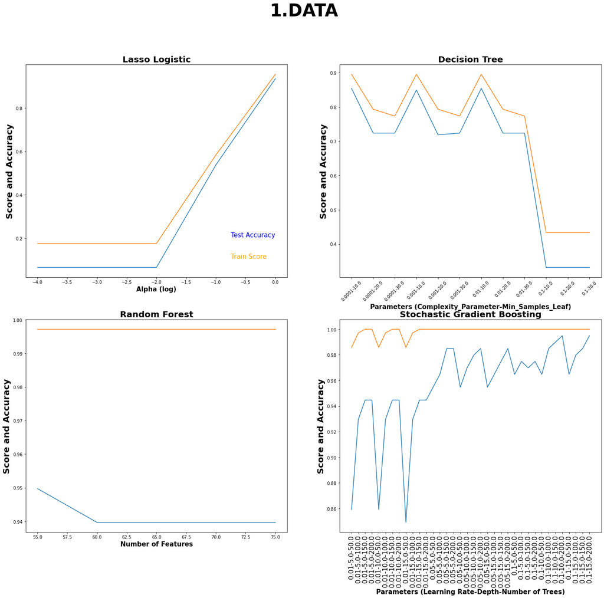

```python
##PLOT RESULTS FOR 1.DATA

fig, axs = plt.subplots(2, 2,figsize=(24,20))
fig.suptitle('1.DATA',fontsize=40,fontweight='bold')
##lASSO
axs[0, 0].plot(np.log10(LL_1['Alpha']),LL_1['Test Accuracy'])
axs[0, 0].plot(np.log10(LL_1['Alpha']),LL_1['Train Score'])
axs[0, 0].set_title('Lasso Logistic',fontsize=20,fontweight='bold')
axs[0, 0].set_ylabel('Score and Accuracy',fontsize=20,fontweight='bold')
axs[0, 0].set_xlabel('Alpha (log)',fontsize=15,fontweight='bold')
axs[0, 0].text(-0.75, 0.2, 'Test Accuracy',verticalalignment='bottom', horizontalalignment='left', color='blue', fontsize=15)
axs[0, 0].text(-0.75, 0.1, 'Train Score',verticalalignment='bottom', horizontalalignment='left', color='orange', fontsize=15)

#DECISION TREE
axs[0, 1].plot(DT_1['Parameters'],DT_1['Test Accuracy'])
axs[0, 1].plot(DT_1['Parameters'],DT_1['Train Score'])
axs[0, 1].set_title('Decision Tree',fontsize=20,fontweight='bold')
axs[0, 1].set_ylabel('Score and Accuracy',fontsize=20,fontweight='bold')
axs[0, 1].set_xticklabels(DT_1['Parameters'],rotation=45,size = 10)
axs[0, 1].set_xlabel('Parameters (Complexity_Parameter-Min_Samples_Leaf)',fontsize=15,fontweight='bold')

###RANDOM FOREST
axs[1, 0].plot(RF_1['Min_Num_Observations'],RF_1['Test Accuracy'])
axs[1, 0].plot(RF_1['Min_Num_Observations'],RF_1['Train Score'])
axs[1, 0].set_title('Random Forest',fontsize=20,fontweight='bold')
axs[1, 0].set_ylabel('Score and Accuracy',fontsize=20,fontweight='bold')
axs[1, 0].set_xlabel('Number of Features',fontsize=15,fontweight='bold')

#STOCHASTIC GRADIENT BOOSTING
axs[1, 1].plot(SGB_1['Parameters'],SGB_1['Test Accuracy'])
axs[1, 1].plot(SGB_1['Parameters'],SGB_1['Train Score'])
axs[1, 1].set_xticklabels(SGB_1['Parameters'],rotation=90,size = 15)
axs[1, 1].set_title('Stochastic Gradient Boosting',fontsize=20,fontweight='bold')
axs[1, 1].set_ylabel('Score and Accuracy',fontsize=20,fontweight='bold')
axs[1, 1].set_xlabel('Parameters (Learning Rate-Depth-Number of Trees)',fontsize=15,fontweight='bold')
```

In the top-right graph, complexity parameter and minimal number of observations per tree leaf take different values. By looking graph, it can be said that complexity-parameter has remarkable effect on the results rather than min. num. of observations per tree leaf parameter. When the complexity parameter increases from 0.01 to 0.1, score and accuracy decreases dramatically in the graph regardless of the other parameter.On the other hand, when the min.num. of observations per tree leaf parameter is 10, score and accuracy have the better result than other values-20 and 30.

Moreover, according to left-bottom graph, random forest gives better result than lasso and decision tree. However, in training data results are same regardless of number of feature, also it can be said that overfitting exists for this data. But, test results in terms of accuracy are still successfull. They are approximately 0.94.

Finally, in the stochastic gradient boosting algorithm, there is overfit in some parameters for the training data. However, the best result is reached with learning rate 0.1, depth 15 and number of trees 200. The test accuracy with those parameters in the last algorithm is the best among all algorithms with the accuracy value of 0.99.

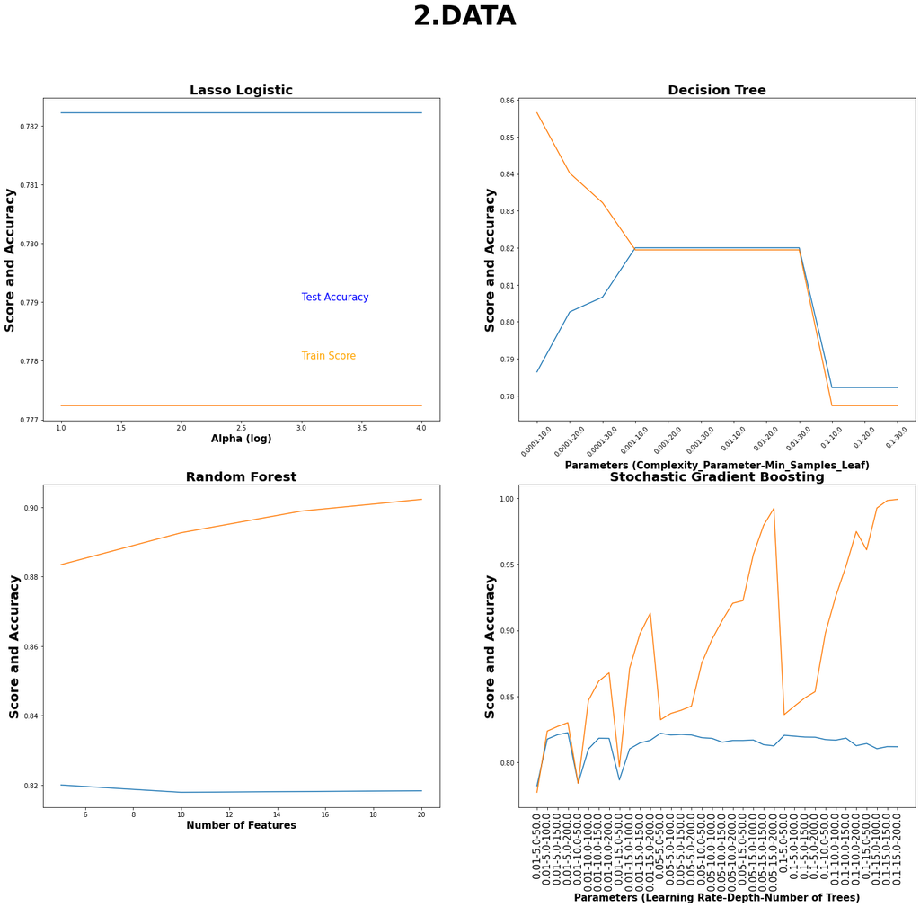

```python
##PLOT RESULTS FOR 2.DATA

fig, axs = plt.subplots(2, 2,figsize=(24,20))
fig.suptitle('2.DATA',fontsize=40,fontweight='bold')
axs[0, 0].plot(LL_2['Alpha'],LL_2['Test Accuracy'])
axs[0, 0].plot(LL_2['Alpha'],LL_2['Train Score'])
axs[0, 0].set_title('Lasso Logistic',fontsize=20,fontweight='bold')
axs[0, 0].set_ylabel('Score and Accuracy',fontsize=20,fontweight='bold')
axs[0, 0].set_xlabel('Alpha (log)',fontsize=15,fontweight='bold')
axs[0, 0].text(3, 0.779, 'Test Accuracy',verticalalignment='bottom', horizontalalignment='left', color='blue', fontsize=15)
axs[0, 0].text(3, 0.778, 'Train Score',verticalalignment='bottom', horizontalalignment='left', color='orange', fontsize=15)



axs[0, 1].plot(DT_2['Parameters'],DT_2['Test Accuracy'])
axs[0, 1].plot(DT_2['Parameters'],DT_2['Train Score'])
axs[0, 1].set_title('Decision Tree',fontsize=20,fontweight='bold')
axs[0, 1].set_ylabel('Score and Accuracy',fontsize=20,fontweight='bold')
axs[0, 1].set_xticklabels(DT_2['Parameters'],rotation=45,size = 10)
axs[0, 1].set_xlabel('Parameters (Complexity_Parameter-Min_Samples_Leaf)',fontsize=15,fontweight='bold')


axs[1, 0].plot(RF_2['Min_Num_Observations'],RF_2['Test Accuracy'])
axs[1, 0].plot(RF_2['Min_Num_Observations'],RF_2['Train Score'])
axs[1, 0].set_title('Random Forest',fontsize=20,fontweight='bold')
axs[1, 0].set_ylabel('Score and Accuracy',fontsize=20,fontweight='bold')
axs[1, 0].set_xlabel('Number of Features',fontsize=15,fontweight='bold')

axs[1, 1].plot(SGB_2['Parameters'],SGB_2['Test Accuracy'])
axs[1, 1].plot(SGB_2['Parameters'],SGB_2['Train Score'])
axs[1, 1].set_xticklabels(SGB_2['Parameters'],rotation=90,size = 15)
axs[1, 1].set_title('Stochastic Gradient Boosting',fontsize=20,fontweight='bold')
axs[1, 1].set_ylabel('Score and Accuracy',fontsize=20,fontweight='bold')
axs[1, 1].set_xlabel('Parameters (Learning Rate-Depth-Number of Trees)',fontsize=15,fontweight='bold')
```

For the 2.Data, different alpha values for lasso logistic give same result in score and accuracy. Altough there is no very huge difference between score and accuracy, interestingly test accuracy is slightly better than train score. This case does not change with any alpha value I try. This situation may be stem from data.

In the top-right graph, complexity parameter and min. samples leaf parameter take different values. By looking graph, it can be said that train score has the best result when complexity parameter and min. samples leaf take the value of 0.0001 and 10, respectively. On the other hand, test accuracy has the best result when complexity parameter is 0.001 and 0.01 with the value of 0.82. Also, both train score and test accuracy have the worst results when the complexity parameter is 0.1. For those reasons, it may be the better strategy to set complexity parameter as 0.001 or 0.01, in these points, train score and test accuracy are getting closer to each other.

Moreover, according to left-bottom graph, random forest gives better result than lasso and decision tree. Train score increases with the increase in number of feature and this converges to 0.90. On the other hand, test accuracy is approximately 0.82 for all number of feature.

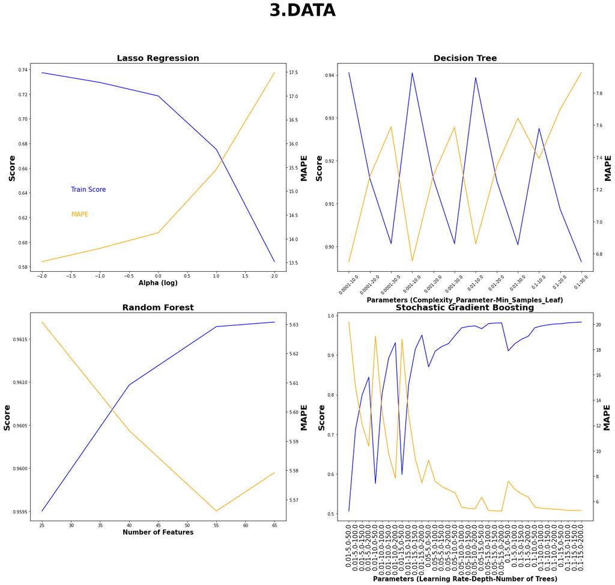

```python
##PLOT RESULTS FOR 3.DATA

fig, axs = plt.subplots(2, 2,figsize=(24,20))
fig.suptitle('3.DATA',fontsize=40,fontweight='bold')
axs[0, 0].plot(np.log10(LR_3['Alpha']),LR_3['Train Score'],color='blue')
axs0 = axs[0,0].twinx()
axs0.plot(np.log10(LR_3['Alpha']),LR_3['MAPE'],color='orange')
axs[0, 0].set_title('Lasso Regression',fontsize=20,fontweight='bold')
axs[0, 0].set_ylabel('Score',fontsize=20,fontweight='bold')
axs0.set_ylabel('MAPE',fontsize=20,fontweight='bold')
axs[0, 0].set_xlabel('Alpha (log)',fontsize=15,fontweight='bold')
axs[0, 0].text(-1.5, 0.64, 'Train Score',verticalalignment='bottom', horizontalalignment='left', color='blue', fontsize=15)
axs[0, 0].text(-1.5, 0.62, 'MAPE',verticalalignment='bottom', horizontalalignment='left', color='orange', fontsize=15)

axs[0, 1].plot(DT_3['Parameters'],DT_3['Train Score'],color='blue')
axs1 = axs[0,1].twinx()
axs1.plot(DT_3['Parameters'],DT_3['MAPE'],color='orange')
axs[0, 1].set_title('Decision Tree',fontsize=20,fontweight='bold')
axs[0, 1].set_ylabel('Score',fontsize=20,fontweight='bold')
axs1.set_ylabel('MAPE',fontsize=20,fontweight='bold')
axs[0, 1].set_xticklabels(DT_3['Parameters'],rotation=45,size = 10)
axs[0, 1].set_xlabel('Parameters (Complexity_Parameter-Min_Samples_Leaf)',fontsize=15,fontweight='bold')


axs[1, 0].plot(RF_3['Min_Num_Observations'],RF_3['Train Score'],color='blue')
axs2=axs[1,0].twinx()
axs2.plot(RF_3['Min_Num_Observations'],RF_3['MAPE'],color='orange')
axs[1, 0].set_title('Random Forest',fontsize=20,fontweight='bold')
axs[1, 0].set_ylabel('Score',fontsize=20,fontweight='bold')
axs2.set_ylabel('MAPE',fontsize=20,fontweight='bold')
axs[1, 0].set_xlabel('Number of Features',fontsize=15,fontweight='bold')

axs[1, 1].plot(SGB_3['Parameters'],SGB_3['Train Score'],color='blue')
axs3=axs[1,1].twinx()
axs3.plot(SGB_3['Parameters'],SGB_3['MAPE'],color='orange')
axs[1, 1].set_xticklabels(SGB_3['Parameters'],rotation=90,size = 15)
axs[1, 1].set_title('Stochastic Gradient Boosting',fontsize=20,fontweight='bold')
axs[1, 1].set_ylabel('Score',fontsize=20,fontweight='bold')
axs3.set_ylabel('MAPE',fontsize=20,fontweight='bold')
axs[1, 1].set_xlabel('Parameters (Learning Rate-Depth-Number of Trees)',fontsize=15,fontweight='bold')
```

For the 3.Data whose output is continuous so there is a regression problem, different alpha values for lasso cause very different results in terms of score and MAPE. When the alpha is 10^-2, train score and MAPE value of test data give the best result for lasso regression. Also, it should be noticed that score in regression problem is R^2. Moreover, there is no interesting case between training and test data, there must be an inverse relation between score and MAPE values. This is true for all algorithms in the graphs.

In the top-right graph, complexity parameter and min. samples leaf parameter take different values. By looking graph, it can be said complexity parameter does not affect the results remarkably because with different complexity parameter except the last one 0.1, results are approximately same. On the other hand, increase in the min. samples leaf parameter affects inversely results. With the value of 10 for min. samples leaf, algorithm gives the best result, it is 0.94 for train score and 6.8 for MAPE in the test data.

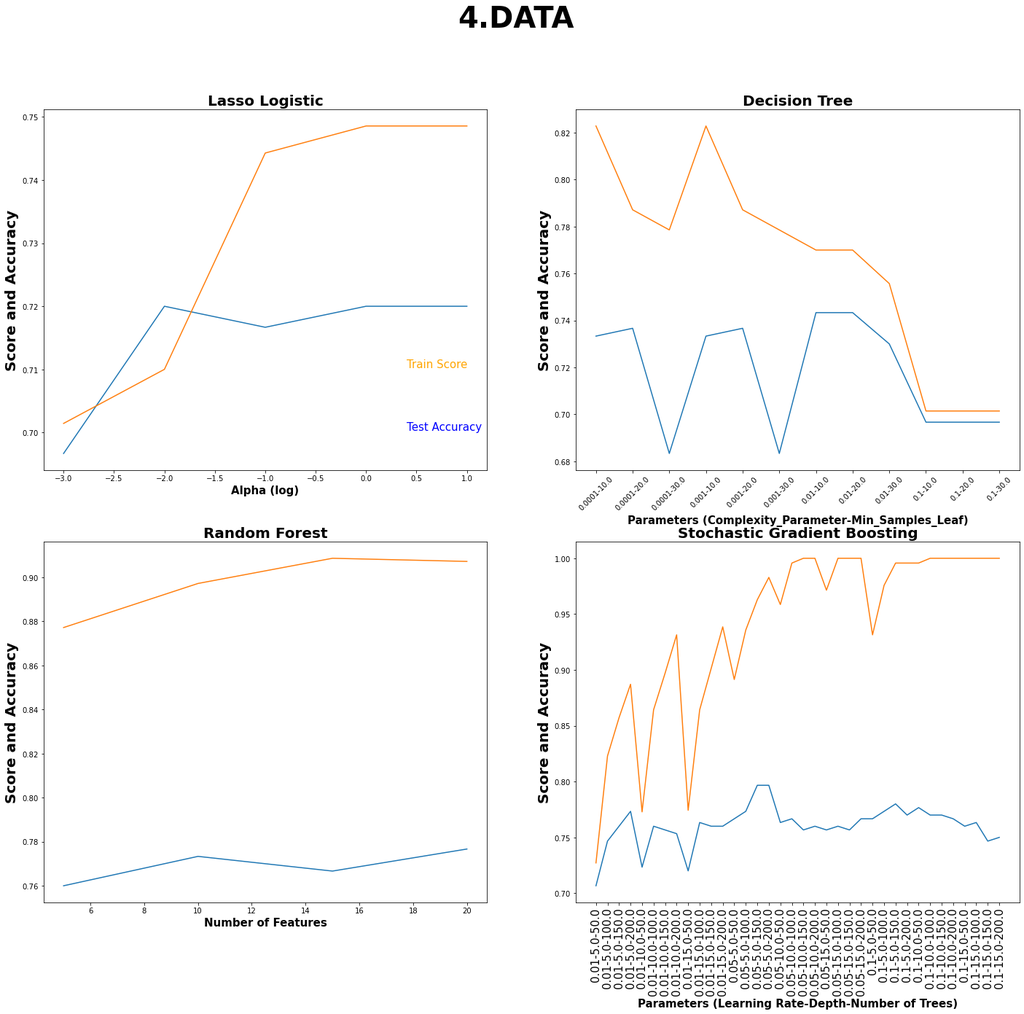

```python
##PLOT RESULTS FOR 4.DATA

fig, axs = plt.subplots(2, 2,figsize=(24,20))
fig.suptitle('4.DATA',fontsize=40,fontweight='bold')
axs[0, 0].plot(np.log10(LL_4['Alpha']),LL_4['Test Accuracy'])
axs[0, 0].plot(np.log10(LL_4['Alpha']),LL_4['Train Score'])
axs[0, 0].set_title('Lasso Logistic',fontsize=20,fontweight='bold')
axs[0, 0].set_ylabel('Score and Accuracy',fontsize=20,fontweight='bold')
axs[0, 0].set_xlabel('Alpha (log)',fontsize=15,fontweight='bold')
axs[0, 0].text(0.4, 0.70, 'Test Accuracy',verticalalignment='bottom', horizontalalignment='left', color='blue', fontsize=15)
axs[0, 0].text(0.4, 0.71, 'Train Score',verticalalignment='bottom', horizontalalignment='left', color='orange', fontsize=15)

axs[0, 1].plot(DT_4['Parameters'],DT_4['Test Accuracy'])
axs[0, 1].plot(DT_4['Parameters'],DT_4['Train Score'])
axs[0, 1].set_title('Decision Tree',fontsize=20,fontweight='bold')
axs[0, 1].set_ylabel('Score and Accuracy',fontsize=20,fontweight='bold')

axs[0, 1].set_xticklabels(DT_4['Parameters'],rotation=45,size = 10)
axs[0, 1].set_xlabel('Parameters (Complexity_Parameter-Min_Samples_Leaf)',fontsize=15,fontweight='bold')


axs[1, 0].plot(RF_4['Min_Num_Observations'],RF_4['Test Accuracy'])
axs[1, 0].plot(RF_4['Min_Num_Observations'],RF_4['Train Score'])
axs[1, 0].set_title('Random Forest',fontsize=20,fontweight='bold')
axs[1, 0].set_ylabel('Score and Accuracy',fontsize=20,fontweight='bold')
axs[1, 0].set_xlabel('Number of Features',fontsize=15,fontweight='bold')

axs[1, 1].plot(SGB_4['Parameters'],SGB_4['Test Accuracy'])
axs[1, 1].plot(SGB_4['Parameters'],SGB_4['Train Score'])
axs[1, 1].set_xticklabels(SGB_4['Parameters'],rotation=90,size = 15)
axs[1, 1].set_title('Stochastic Gradient Boosting',fontsize=20,fontweight='bold')
axs[1, 1].set_ylabel('Score and Accuracy',fontsize=20,fontweight='bold')
axs[1, 1].set_xlabel('Parameters (Learning Rate-Depth-Number of Trees)',fontsize=15,fontweight='bold')
```

For the 4.Data, in the lasso logistic, increase in the alpha causes to rise in train score and test accuracy, but that raise reachs limit 0.75 for train score and 0.72 for test accuracy. With the value of alpha 10^0 (1), results reach the best values.

In the top-right graph, complexity parameter and min. samples leaf parameter take different values. By looking graph, it can be said that at the value of min samples leaf 20, test accuracy gives the best results. On the other hand, eventhough increase in the complexity parameter causes to decrease in the train score, complexity parameter does not affect significantly test accuracy. Test accuracy is affected by min samples leaf parameter mainly. At the point in which complexity parameter is 0.01 and min samples leaf parameter is 10 or 20, test accuracy has the best result with the value 0.74. Moreover, with complexity parameter 0.001 train score gives better result, but, test accuracy is slightly worse than results at the point where complexity parameter 0.01.

# RESULTS WITH TABLE

1. DATA

```python
display(LL_1.sort_values('Test Accuracy', ascending= False))
display(RF_1.sort_values('Test Accuracy', ascending= False))
```

|  | Alpha | Train Score | Test Accuracy |
| --- | --- | --- | --- |
| 4 | 1.0000 | 0.954674 | 0.934673 |
| 3 | 0.1000 | 0.583569 | 0.537688 |
| 0 | 0.0001 | 0.175637 | 0.065327 |
| 1 | 0.0010 | 0.175637 | 0.065327 |
| 2 | 0.0100 | 0.175637 | 0.065327 |

|  | Min_Num_Observations | Train Score | Test Accuracy |
| --- | --- | --- | --- |
| 0 | 55 | 0.997167 | 0.949749 |
| 1 | 60 | 0.997167 | 0.939698 |
| 2 | 70 | 0.997167 | 0.939698 |
| 3 | 75 | 0.997167 | 0.939698 |

```python
display(DT_1.sort_values('Test Accuracy', ascending= False).head())
display(SGB_1.sort_values('Test Accuracy', ascending= False).head())
## there are 36 combination for this reason just show five best results.
```

|  | Complexity_Parameter | Min_Samples_Leaf | Train Score | Test Accuracy | Parameters |
| --- | --- | --- | --- | --- | --- |
| 0 | 0.0001 | 10.0 | 0.895184 | 0.854271 | 0.0001-10.0 |
| 6 | 0.0100 | 10.0 | 0.895184 | 0.854271 | 0.01-10.0 |
| 3 | 0.0010 | 10.0 | 0.895184 | 0.849246 | 0.001-10.0 |
| 1 | 0.0001 | 20.0 | 0.793201 | 0.723618 | 0.0001-20.0 |
| 2 | 0.0001 | 30.0 | 0.773371 | 0.723618 | 0.0001-30.0 |

|  | Learning Rate | Depth | Number of Trees | Train Score | Test Accuracy | Parameters |
| --- | --- | --- | --- | --- | --- | --- |
| 35 | 0.10 | 15.0 | 200.0 | 1.0 | 0.994975 | 0.1-15.0-200.0 |
| 31 | 0.10 | 10.0 | 200.0 | 1.0 | 0.994975 | 0.1-10.0-200.0 |
| 30 | 0.10 | 10.0 | 150.0 | 1.0 | 0.989950 | 0.1-10.0-150.0 |
| 14 | 0.05 | 5.0 | 150.0 | 1.0 | 0.984925 | 0.05-5.0-150.0 |
| 34 | 0.10 | 15.0 | 150.0 | 1.0 | 0.984925 | 0.1-15.0-150.0 |

1. DATA

```python
display(LL_2.sort_values('Test Accuracy', ascending= False))
display(RF_2.sort_values('Test Accuracy', ascending= False))
display(DT_2.sort_values('Test Accuracy', ascending= False).head())
display(SGB_2.sort_values('Test Accuracy', ascending= False).head())
## there are 36 combination for this reason just show five best results.
```

|  | Alpha | Train Score | Test Accuracy |
| --- | --- | --- | --- |
| 0 | 1 | 0.777238 | 0.782222 |
| 1 | 2 | 0.777238 | 0.782222 |
| 2 | 3 | 0.777238 | 0.782222 |
| 3 | 4 | 0.777238 | 0.782222 |

|  | Min_Num_Observations | Train Score | Test Accuracy |
| --- | --- | --- | --- |
| 0 | 5 | 0.883476 | 0.820000 |
| 3 | 20 | 0.902286 | 0.818333 |
| 2 | 15 | 0.898905 | 0.818111 |
| 1 | 10 | 0.892667 | 0.817889 |

|  | Complexity_Parameter | Min_Samples_Leaf | Train Score | Test Accuracy | Parameters |
| --- | --- | --- | --- | --- | --- |
| 3 | 0.001 | 10.0 | 0.819429 | 0.82 | 0.001-10.0 |
| 4 | 0.001 | 20.0 | 0.819429 | 0.82 | 0.001-20.0 |
| 5 | 0.001 | 30.0 | 0.819429 | 0.82 | 0.001-30.0 |
| 6 | 0.010 | 10.0 | 0.819429 | 0.82 | 0.01-10.0 |
| 7 | 0.010 | 20.0 | 0.819429 | 0.82 | 0.01-20.0 |

|  | Learning Rate | Depth | Number of Trees | Train Score | Test Accuracy | Parameters |
| --- | --- | --- | --- | --- | --- | --- |
| 3 | 0.01 | 5.0 | 200.0 | 0.830048 | 0.822444 | 0.01-5.0-200.0 |
| 12 | 0.05 | 5.0 | 50.0 | 0.832238 | 0.822000 | 0.05-5.0-50.0 |
| 14 | 0.05 | 5.0 | 150.0 | 0.839429 | 0.821111 | 0.05-5.0-150.0 |
| 2 | 0.01 | 5.0 | 150.0 | 0.827143 | 0.820889 | 0.01-5.0-150.0 |
| 13 | 0.05 | 5.0 | 100.0 | 0.837048 | 0.820667 | 0.05-5.0-100.0 |

3.DATA

```python
display(LR_3.sort_values('MAPE'))
display(RF_3.sort_values('MAPE'))
display(DT_3.sort_values('MAPE').head())
display(SGB_3.sort_values('MAPE').head())
## there are 36 combination for this reason just show five best results.
```

|  | Alpha | Train Score | MAPE | RMSE |
| --- | --- | --- | --- | --- |
| 0 | 0.01 | 0.737359 | 13.519781 | 17.865317 |
| 1 | 0.10 | 0.729399 | 13.798999 | 18.166252 |
| 2 | 1.00 | 0.718525 | 14.125668 | 18.525917 |
| 3 | 10.00 | 0.675208 | 15.456333 | 19.890526 |
| 4 | 100.00 | 0.584195 | 17.486733 | 22.277315 |

|  | Min_Num_Observations | Train Score | MAPE | RMSE |
| --- | --- | --- | --- | --- |
| 2 | 55 | 0.961644 | 5.566070 | 9.780430 |
| 3 | 65 | 0.961696 | 5.579224 | 9.816133 |
| 1 | 40 | 0.960966 | 5.593610 | 9.792205 |
| 0 | 25 | 0.959503 | 5.630733 | 9.841474 |

|  | Complexity_Parameter | Min_Samples_Leaf | Train Score | MAPE | RMSE | Parameters |
| --- | --- | --- | --- | --- | --- | --- |
| 0 | 0.0001 | 10.0 | 0.940571 | 6.751163 | 11.894807 | 0.0001-10.0 |
| 3 | 0.0010 | 10.0 | 0.940519 | 6.754912 | 11.895524 | 0.001-10.0 |
| 6 | 0.0100 | 10.0 | 0.939430 | 6.862571 | 11.899597 | 0.01-10.0 |
| 1 | 0.0001 | 20.0 | 0.915761 | 7.283189 | 12.347216 | 0.0001-20.0 |
| 4 | 0.0010 | 20.0 | 0.915750 | 7.288397 | 12.366335 | 0.001-20.0 |

|  | Learning Rate | Depth | Number of Trees | Train Score | MAPE | RMSE | Parameters |
| --- | --- | --- | --- | --- | --- | --- | --- |
| 23 | 0.05 | 15.0 | 200.0 | 0.981462 | 5.234826 | 9.482249 | 0.05-15.0-200.0 |
| 22 | 0.05 | 15.0 | 150.0 | 0.980835 | 5.245450 | 9.499006 | 0.05-15.0-150.0 |
| 34 | 0.10 | 15.0 | 150.0 | 0.982405 | 5.285536 | 9.598728 | 0.1-15.0-150.0 |
| 21 | 0.05 | 15.0 | 100.0 | 0.979238 | 5.286941 | 9.526733 | 0.05-15.0-100.0 |
| 35 | 0.10 | 15.0 | 200.0 | 0.983310 | 5.288859 | 9.626256 | 0.1-15.0-200.0 |

4.DATA

```python
display(LL_4.sort_values('Test Accuracy', ascending= False))
display(RF_4.sort_values('Test Accuracy', ascending= False))
display(DT_4.sort_values('Test Accuracy', ascending= False).head())
display(SGB_4.sort_values('Test Accuracy', ascending= False).head())
## there are 36 combination for this reason just show five best results.
```

|  | Alpha | Train Score | Test Accuracy |
| --- | --- | --- | --- |
| 1 | 0.010 | 0.710000 | 0.720000 |
| 3 | 1.000 | 0.748571 | 0.720000 |
| 4 | 10.000 | 0.748571 | 0.720000 |
| 2 | 0.100 | 0.744286 | 0.716667 |
| 0 | 0.001 | 0.701429 | 0.696667 |

|  | Min_Num_Observations | Train Score | Test Accuracy |
| --- | --- | --- | --- |
| 3 | 20 | 0.907143 | 0.776667 |
| 1 | 10 | 0.897143 | 0.773333 |
| 2 | 15 | 0.908571 | 0.766667 |
| 0 | 5 | 0.877143 | 0.760000 |

|  | Complexity_Parameter | Min_Samples_Leaf | Train Score | Test Accuracy | Parameters |
| --- | --- | --- | --- | --- | --- |
| 6 | 0.0100 | 10.0 | 0.770000 | 0.743333 | 0.01-10.0 |
| 7 | 0.0100 | 20.0 | 0.770000 | 0.743333 | 0.01-20.0 |
| 1 | 0.0001 | 20.0 | 0.787143 | 0.736667 | 0.0001-20.0 |
| 4 | 0.0010 | 20.0 | 0.787143 | 0.736667 | 0.001-20.0 |
| 0 | 0.0001 | 10.0 | 0.822857 | 0.733333 | 0.0001-10.0 |

|  | Learning Rate | Depth | Number of Trees | Train Score | Test Accuracy | Parameters |
| --- | --- | --- | --- | --- | --- | --- |
| 15 | 0.05 | 5.0 | 200.0 | 0.982857 | 0.796667 | 0.05-5.0-200.0 |
| 14 | 0.05 | 5.0 | 150.0 | 0.962857 | 0.796667 | 0.05-5.0-150.0 |
| 26 | 0.10 | 5.0 | 150.0 | 0.995714 | 0.780000 | 0.1-5.0-150.0 |
| 28 | 0.10 | 10.0 | 50.0 | 0.995714 | 0.776667 | 0.1-10.0-50.0 |
| 13 | 0.05 | 5.0 | 100.0 | 0.935714 | 0.773333 | 0.05-5.0-100.0 |

# QUESTIONS

a. Is the cross-validation error rate of different approaches consistent with the test error rate?

In all algotihms, train score and test accuracy show similar behavior with different parameters. However, in some cases, while train score is increasing test accuracy reachs its limit. But, still, it can be said that, error rate of different approaches are consinstent with the test error rate, generally.

b. What is your observation about the performance of the classifiers over all datasets?

I compare the training and test error as follows: their trend or behavior with different parameter or parameters combination. In some cases, while training score still increasing, test accuracy does not change remarkably. To illustate, for 4.Data with stochastic gradient boosting algorithm, train score reach the 1.0; however, test accuracy cannot increase itself. This situation is overfitting.

To sum up, this behavior and results are indications of underfittin and overfitting as I explained.